# R-Packages

Amitai Asaf

2023-12-26

# Setup

### Load librarys and data

```r
library(tidytuesdayR)
library(tidyverse)
library(igraph)
library(ggplot2)

last_tuesday()
r_data <- tt_load("2023-12-26")
```

# inspect data

```r
map(r_data,glimpse)
```

```
## Rows: 24,095
## Columns: 94
## $ package                    <chr> "A3", "AATtools", "ABACUS", "abbreviate", "…
## $ version                    <chr> "1.0.0", "0.0.2", "1.0.0", "0.1", "0.5.5", …
## $ date                       <dttm> 2015-08-16 23:05:52, 2022-08-12 13:40:09, …
## $ license                    <chr> "GPL (>= 2)", "GPL-3", "GPL-3", "GPL-3", "M…
## $ files_R                    <dbl> 2, 15, 7, 1, 20, 8, 0, 10, 8, 10, 3, 6, 15,…
## $ files_src                  <dbl> 0, 0, 0, 0, 0, 0, 0, 0, 7, 0, 2, 0, 7, 0, 0…
## $ files_inst                 <dbl> 0, 0, 0, 0, 0, 0, 0, 0, 0, 0, 0, 0, 0, 0, 0…
## $ files_vignettes            <dbl> 0, 0, 2, 0, 3, 3, 0, 1, 0, 0, 0, 0, 0, 0, 0…
## $ files_tests                <dbl> 0, 0, 0, 2, 7, 0, 0, 0, 0, 0, 2, 0, 0, 0, 0…
## $ loc_R                      <dbl> 365, 1432, 28, 51, 518, 1310, NA, 123, 380,…
## $ loc_src                    <dbl> NA, NA, NA, NA, NA, NA, NA, NA, 898, NA, 23…
## $ loc_inst                   <dbl> NA, NA, NA, NA, NA, NA, NA, NA, NA, NA, NA,…
## $ loc_vignettes              <dbl> NA, NA, 554, NA, 274, 539, NA, 97, NA, NA, …
```

[output cut: 92 more lines]

```
## $cran_20221122
## # A tibble: 24,095 × 94
##    package     version date                license  files_R files_src files_inst
##    <chr>       <chr>   <dttm>              <chr>      <dbl>     <dbl>      <dbl>
##  1 A3          1.0.0   2015-08-16 23:05:52 GPL (>=…       2         0          0
##  2 AATtools    0.0.2   2022-08-12 13:40:09 GPL-3         15         0          0
##  3 ABACUS      1.0.0   2019-09-20 07:40:06 GPL-3          7         0          0
##  4 abbreviate  0.1     2021-12-14 08:40:04 GPL-3          1         0          0
##  5 abbyyR      0.5.5   2019-06-25 04:30:04 MIT + f…      20         0          0
##  6 abc         2.2.1   2022-05-19 07:20:02 GPL (>=…       8         0          0
##  7 abc.data    1.0     2015-05-05 11:34:13 GPL (>=…       0         0          0
##  8 ABC.RAP     0.9.0   2016-10-20 10:52:16 GPL-3         10         0          0
##  9 abcADM      1.0     2019-11-13 14:50:02 GPL-3          8         7          0
## 10 ABCanalysis 1.2.1   2017-03-13 14:31:38 GPL-3         10         0          0
## # ℹ 24,085 more rows
## # ℹ 87 more variables: files_vignettes <dbl>, files_tests <dbl>, loc_R <dbl>,
## #   loc_src <dbl>, loc_inst <dbl>, loc_vignettes <dbl>, loc_tests <dbl>,
## #   blank_lines_R <dbl>, blank_lines_src <dbl>, blank_lines_inst <dbl>,
## #   blank_lines_vignettes <dbl>, blank_lines_tests <dbl>,
## #   comment_lines_R <dbl>, comment_lines_src <dbl>, comment_lines_inst <dbl>,
## #   comment_lines_vignettes <dbl>, comment_lines_tests <dbl>, …
##
## $external_calls
## # A tibble: 154,139 × 4
##    package_from package_to n_total n_unique
##    <chr>        <chr>        <dbl>    <dbl>
##  1 A3           base           243       37
##  2 A3           graphics         7        2
##  3 A3           stats           41       12
##  4 A3           utils           21        1
##  5 AATtools     base          1220       87
##  6 AATtools     dplyr           33        4
##  7 AATtools     foreach          2        1
##  8 AATtools     graphics         2        2
##  9 AATtools     magrittr        84        2
## 10 AATtools     parallel         2        1
## # ℹ 154,129 more rows
##
## $internal_calls
## # A tibble: 22,564 × 3
##    package     n_total n_unique
##    <chr>         <dbl>    <dbl>
##  1 A3               37       20
##  2 AATtools        170       99
##  3 abbreviate        1        1
##  4 abbyyR           22       12
##  5 abc              24       17
##  6 ABC.RAP          12        7
##  7 abcADM           17       16
##  8 ABCanalysis      24       11
##  9 ABCoptim          9        8
## 10 abcrf            30       25
## # ℹ 22,554 more rows
```

# SNA

### Focus

The three data sets provide a lot of data as expected from a database collecting data about R packages. This could be a bit overwhelming, but with a small glimpse the second data frame catches the eye. The second data frame, also called external calls, lists the amount of calls each R package makes to another R-package.

This type of data could also be thought as an edge list, a list of connections between nodes. Nodes are actors who exist either in the world or as a concept, and they could have relations with other nodes. Together the actors (nodes) and the connections between them (edges) can form a network of connections also known as a social network.

Here I am going to analyze the social network of R-packages and try to learn about the relationships between the packages.

## create basic social network

First we create the basic network

```r
external_calls <- r_data$external_calls

sn <- graph_from_edgelist(cbind(external_calls$package_from,external_calls$package_to))
E(sn)$weight <- external_calls$n_total
```

Then we check how many actors and connections are there in the network

```r
paste("There are",as.character(vcount(sn)) , "actors")
```

```
## [1] "There are 23676 actors"
```

```r
paste("and" , ecount(sn) , "connections between them in the network")
```

```
## [1] "and 154139 connections between them in the network"
```

This makes the network too big for a plot but we can still analyze it.

## centralization measurments

```r
sn_centrality <- data.frame(Package = V(sn)$name,
                            in_degree_cen = degree(sn,mode="in"),
                            out_degree_cen = degree(sn,mode="out"),
                            total = degree(sn,mode="total"),
                            in_strength_cen = strength(sn,mode="in"),
                            out_strength_cen = strength(sn,mode="out"),
                            betweeness_cen = betweenness(sn),
                            in_closeness_cen = closeness(sn,mode="in"),
                            out_closeness_cen = closeness(sn,mode="out"),
                            eigen_cen = eigen_centrality(sn,directed = TRUE)$vector)

sn_centrality <-replace(sn_centrality,is.na(sn_centrality),0)
```

### degree

The degree of an actor is simply the amount of connections the actor have to its neighbors. In degrees represent the amount of packages that calls to a package and out degrees represent the amount of packages a package calls to.

A weighted degree, also called strength is the amount of calls a package make or receive respectively to in and out degrees.

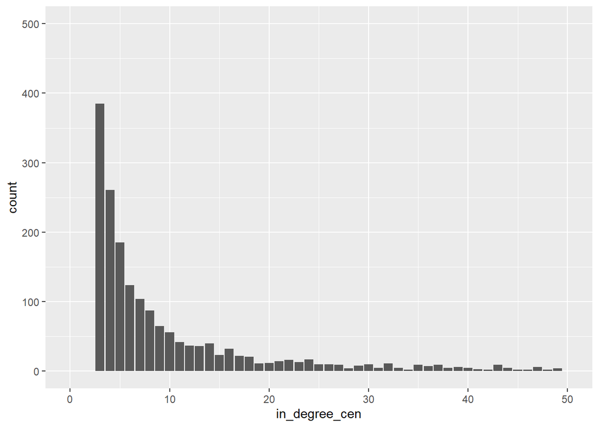

```r
ggplot(sn_centrality, aes(x = in_degree_cen))+
  geom_bar() +
  xlim(0,50)+
  ylim(0,500)
```

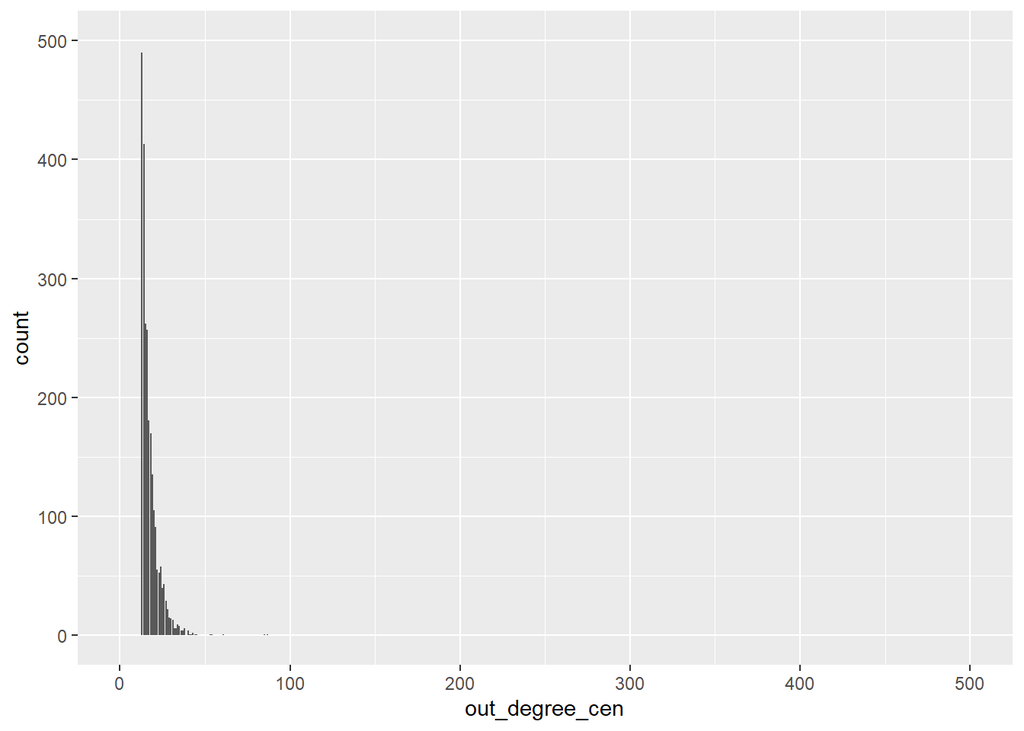

```r
ggplot(sn_centrality, aes(x = out_degree_cen))+
  geom_bar() +
  xlim(0,500) +
  ylim(0,500)
```

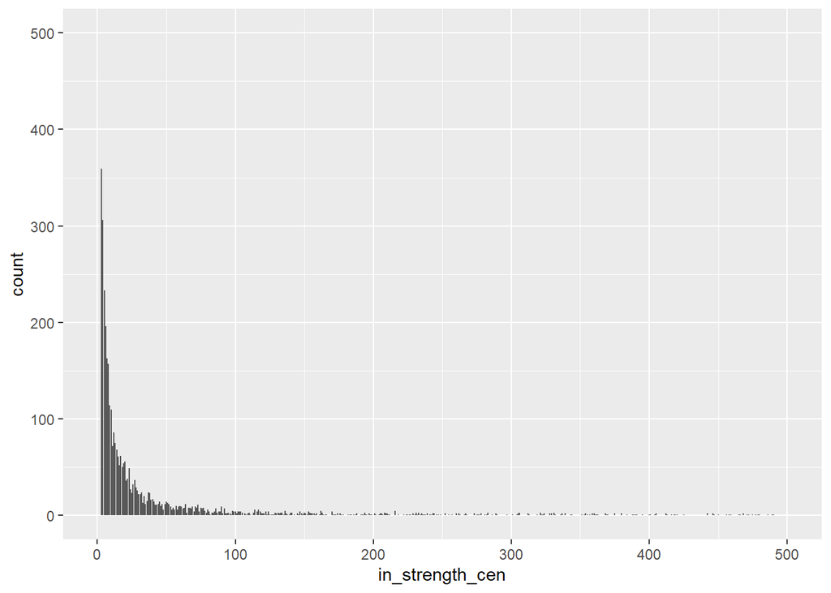

```r
ggplot(sn_centrality, aes(x = in_strength_cen))+
  geom_bar() +
  xlim(0,500)+
  ylim(0,500)
```

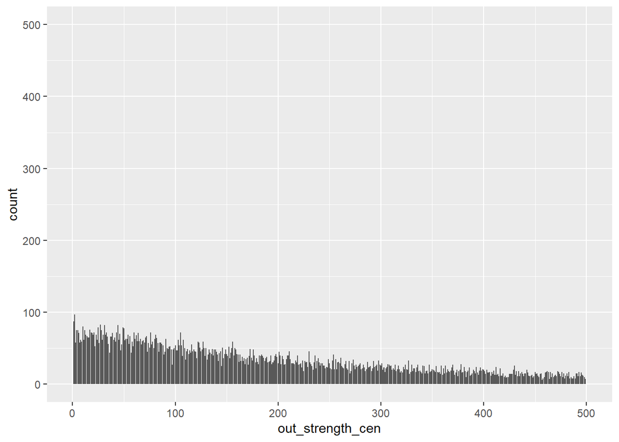

```r
ggplot(sn_centrality, aes(x = out_strength_cen))+
  geom_bar() +
  xlim(0,500) +
  ylim(0,500)
```

Lets look which packages have the highest degrees and strengths

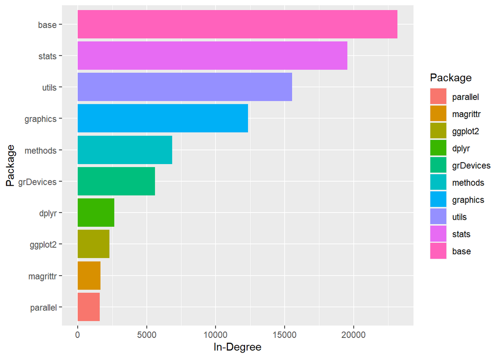

```r
sn_centrality %>%
  mutate(Package = fct_reorder(Package, in_degree_cen)) %>%
    arrange(desc(in_degree_cen)) %>%
      head(10) %>%
        ggplot(aes(x=Package, y=in_degree_cen,fill=Package)) +
          geom_col() +
          ylab("In-Degree") +
          coord_flip()
```

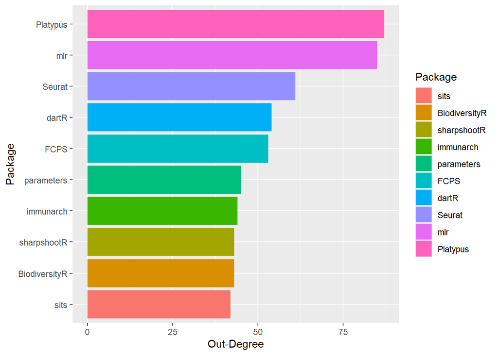

```r
sn_centrality %>%
  mutate(Package = fct_reorder(Package, out_degree_cen)) %>%
    arrange(desc(out_degree_cen)) %>%
      head(10) %>%
        ggplot(aes(x=Package, y=out_degree_cen,fill=Package)) +
          geom_col() +
          ylab("Out-Degree") +
          coord_flip()
```

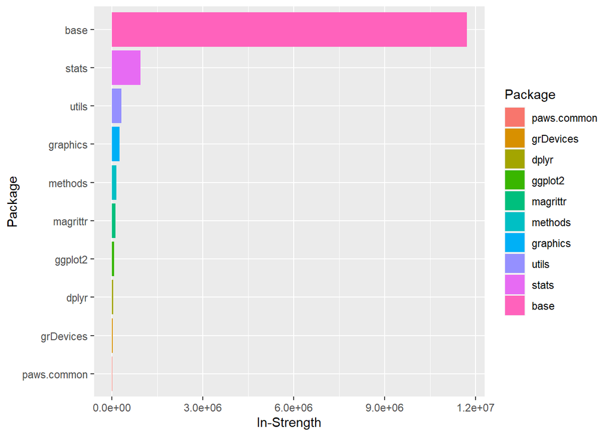

```r
sn_centrality %>%
  mutate(Package = fct_reorder(Package, in_strength_cen)) %>%
    arrange(desc(in_strength_cen)) %>%
      head(10) %>%
        ggplot(aes(x=Package, y=in_strength_cen,fill=Package)) +
          geom_col() +
          ylab("In-Strength") +
          coord_flip()
```

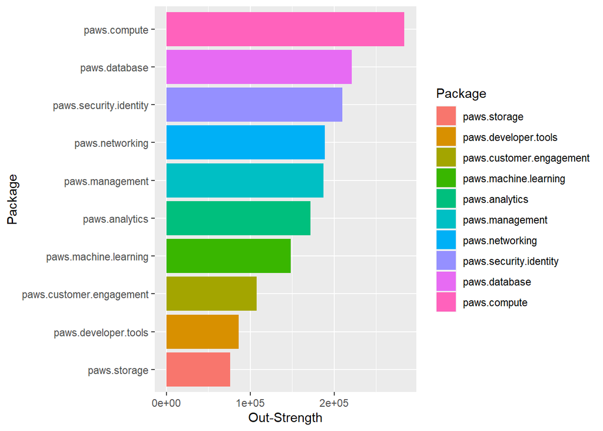

```r
sn_centrality %>%
  mutate(Package = fct_reorder(Package, out_strength_cen)) %>%
    arrange(desc(out_strength_cen)) %>%
      head(10) %>%
        ggplot(aes(x=Package, y=out_strength_cen,fill=Package)) +
          geom_col() +
          ylab("Out-Strength") +
          coord_flip()
```

### Betweeness

Betweenes is a measurement of how many cases an actor stand in the path of 2 other actors. In our case a package may not call a package directly, rather it could call another package that would call the package instead and thus use it indirectly.

Lets view the packages to stand between other packages the most.

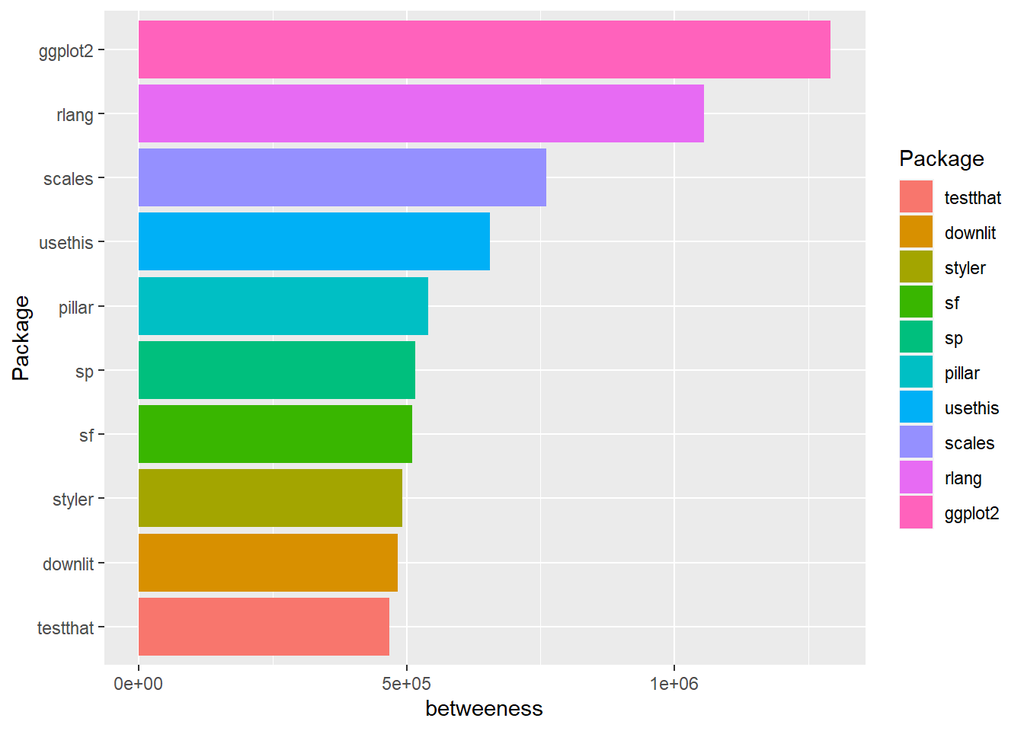

```r
sn_centrality %>%
  mutate(Package = fct_reorder(Package, betweeness_cen)) %>%
    arrange(desc(betweeness_cen)) %>%
      head(10) %>%
        ggplot(aes(x=Package, y=betweeness_cen,fill=Package)) +
          geom_col() +
          ylab("betweeness") +
          coord_flip()
```

### closeness

Closeness measure the sum of shortest distances between one actor and the other actors in means of indirect (or direct) relations

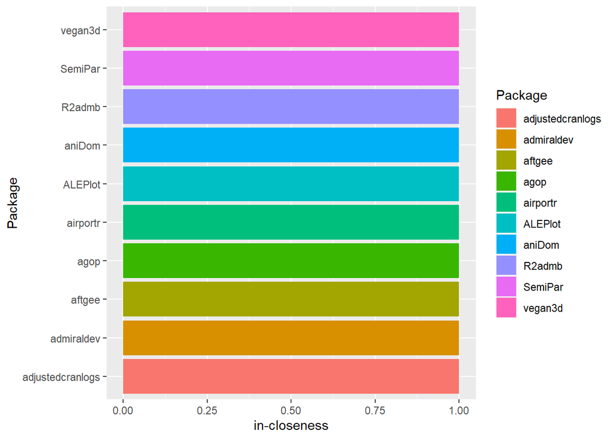

```r
sn_centrality %>%
  mutate(Package = fct_reorder(Package, in_closeness_cen)) %>%
    arrange(desc(in_closeness_cen)) %>%
      head(10) %>%
        ggplot(aes(x=Package, y=in_closeness_cen,fill=Package)) +
          geom_col() +
          ylab("in-closeness") +
          coord_flip()
```

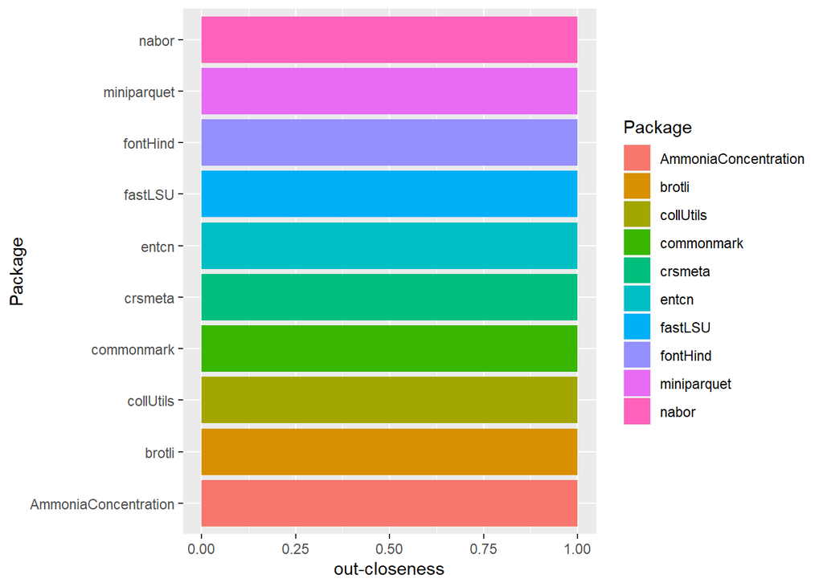

```r
sn_centrality %>%
  mutate(Package = fct_reorder(Package, out_closeness_cen)) %>%
    arrange(desc(out_closeness_cen)) %>%
      head(10) %>%
        ggplot(aes(x=Package, y=out_closeness_cen,fill=Package)) +
          geom_col() +
          ylab("out-closeness") +
          coord_flip()
```

### Eigen Vector

The last measurement is the Eigen Vector. Unlike other measurements the eigen vector is a measurement of the neighboors of an actor rather than the actor itself. It assumes that if an actor is related to a lot of other important actors than it is important itself

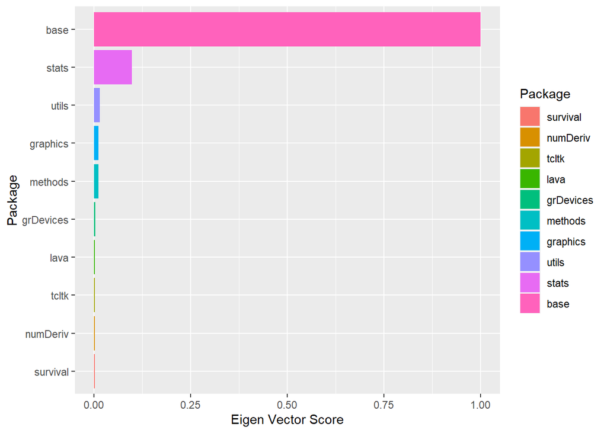

```r
sn_centrality %>%
  mutate(Package = fct_reorder(Package, eigen_cen)) %>%
    arrange(desc(eigen_cen)) %>%
      head(10) %>%
        ggplot(aes(x=Package, y=eigen_cen,fill=Package)) +
          geom_col() +
          ylab("Eigen Vector Score") +
          coord_flip()
```

## Plotting a social network

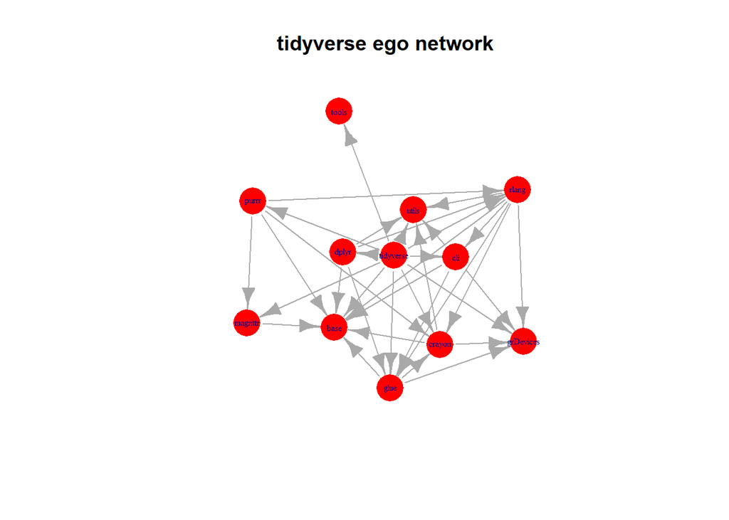

```r
tidyverse_sn <- induced_subgraph(sn,unlist(ego(sn,nodes = "tidyverse")))


plot.igraph(tidyverse_sn,
            layout= layout_with_dh(tidyverse_sn),
            vertex.size = 20,
            vertex.color = "red",
            vertex.label.cex = .5,
            vertex.frame.color = NA,
            layout = layout.fruchterman.reingold,
            main = "tidyverse ego network"
            )
```